# Lecture #6: Surfaces of Revolution

MATH 146 – Calculus II

Torin Quinlivan

tquinlivan@knox.edu

Knox College

December 24, 2025

## Surfaces of Revolution

Given a curve $f(x) \ge 0$ over the interval $[a, b]$, a surface of revolution is the 2D figure obtained by revolving the graph of $f(x)$ around an axis.

$$f(x) = \sqrt{1 - x^2} \,\,\, \textrm{over}\, [-1, 1]$$

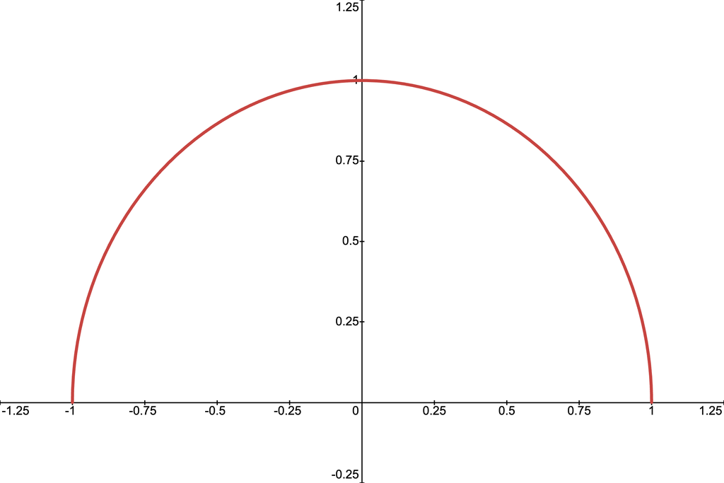

## Common Surfaces of Revolution

$$f(x) = \sqrt{1 - x^2} \,\,\, \textrm{over}\, [-1, 1]$$

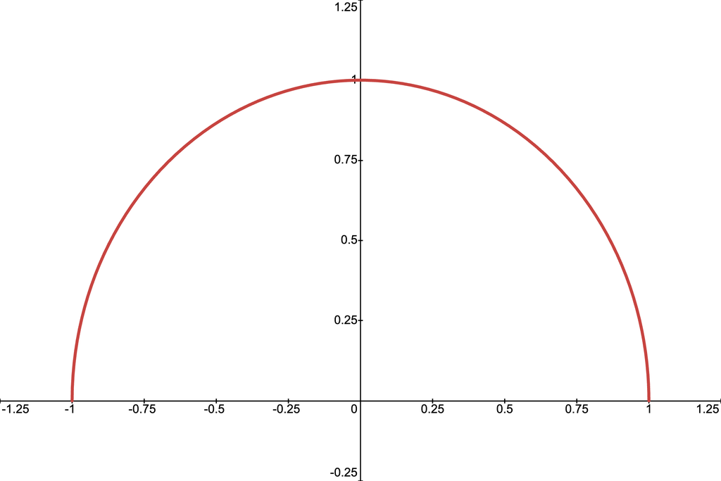

## Common Surfaces of Revolution

What is the *lateral* surface area of a cylinder?

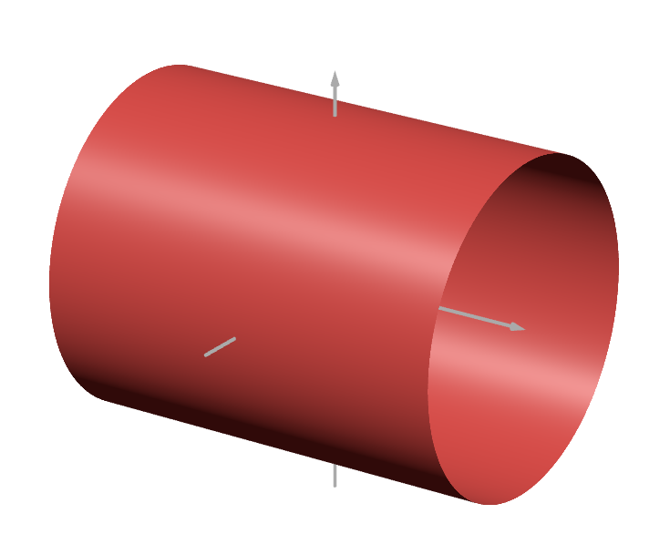

## Center of Gravity of a Curve

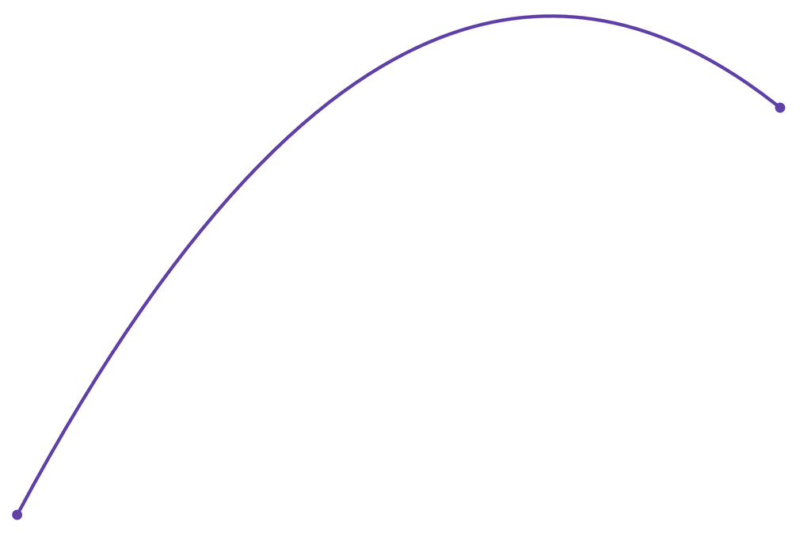

$$\begin{aligned}
m_1 &= \sqrt{(x_i - x_{i-1})^2 + (f(x_i) - f(x_{i-1}))^2} \\
&= \sqrt{(x_i - x_{i-1})^2 + f'(x^*_i)^2(x_i - x_{i-1})^2} \\
&= \sqrt{1 + f(x^*_i)^2} \Delta x
\end{aligned}$$

## Center of Gravity of a Curve

$$\begin{aligned}
\overline{x}_P = \frac{\displaystyle\sum_{i=1}^n m_i\overline{x}_i}{\displaystyle\sum_{i=1}^n m_i} &\approx \frac{\displaystyle\sum_{i=1}^n x_i^* \sqrt{1 + f'(x_i^*)^2} \Delta x}{\displaystyle\sum_{i=1}^n \sqrt{1 + f'(x_i^*)^2} \Delta x} \\[1em]
\overline{y}_P = \frac{\displaystyle\sum_{i=1}^n m_i\overline{y}_i}{\displaystyle\sum_{i=1}^n m_i} &\approx \frac{\displaystyle\sum_{i=1}^n f(x_i^*) \sqrt{1 + f'(x_i^*)^2} \Delta x}{\displaystyle\sum_{i=1}^n \sqrt{1 + f'(x_i^*)^2} \Delta x}
\end{aligned}$$

## Center of Gravity of a Curve

Suppose that $f(x)$ is continuous and differentiable on the interval $[a, b]$. Then the center of gravity of the graph of $f(x)$ is given by:

$$\begin{aligned}
\overline{x} &= \dfrac{\displaystyle\int_a^b x \sqrt{1 + f'(x)^2} dx}{\displaystyle\int_a^b \sqrt{1 + f'(x)^2} dx} & &\textrm{and} & \overline{y} &= \dfrac{\displaystyle\int_a^b f(x) \sqrt{1 + f'(x)^2} dx}{\displaystyle\int_a^b \sqrt{1 + f'(x)^2} dx}
\end{aligned}$$

## Surfaces of Revolution

If a segment of a plane curve $\mathcal{C}$ is revolved around an axis that does not intersect the curve (expect possibly at its endpoints), the are $SA$ of the resulting surface of revolution is given by the product of the length of $\mathcal{C}$ times the distance $d$ traveled by the centroid of $\mathcal{C}$.

$$SA = (\textrm{distance traveled by the center of gravity}) \times (\textrm{arc length})$$

## Surfaces of Revolution

The surface area of a function $f(x) > 0$ over $0 < a < x < b$ when revolved around the $x$-axis is:

$$\begin{aligned}
SA &= 2 \pi \overline{y} \times (\textrm{arc length}) \\
&= 2\pi \left( \dfrac{\displaystyle\int_a^b f(x) \sqrt{1 + f'(x)^2} dx}{\cancel{\displaystyle\int_a^b \sqrt{1 + f'(x)^2} dx}} \right) \left( \cancel{\displaystyle\int_a^b \sqrt{1 + f'(x)^2} dx} \right) \\
&= 2\pi \displaystyle\int_a^b f(x) \sqrt{1 + f'(x)^2} dx
\end{aligned}$$

## Surfaces of Revolution

The surface area of a function $f(x) > 0$ over $0 < a < x < b$ when revolved around the $y$-axis is:

$$\begin{aligned}
SA &= 2 \pi \overline{x} \times (\textrm{arc length}) \\
&= 2\pi \left( \dfrac{\displaystyle\int_a^b x \sqrt{1 + f'(x)^2} dx}{\cancel{\displaystyle\int_a^b \sqrt{1 + f'(x)^2} dx}} \right) \left( \cancel{\displaystyle\int_a^b \sqrt{1 + f'(x)^2} dx} \right) \\
&= 2\pi \displaystyle\int_a^b x \sqrt{1 + f'(x)^2} dx
\end{aligned}$$

## Example: Surfaces of Revolution

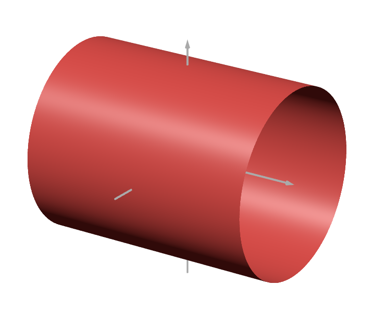

## Example: Surfaces of Revolution

**Example:** Prove that the (lateral) surface area of a cone of height $h$ and base radius $r$ is $SA = \pi r l = \pi r \sqrt{r^2 + h^2}$.

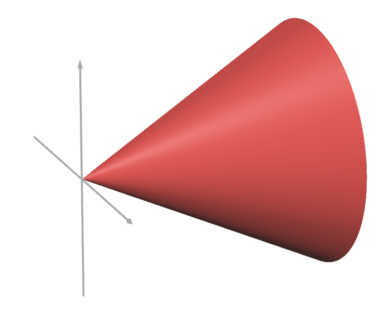